# Advanced Bioinformatics 2023 assessment

## R Markdown: RNA-seq assessment

Task 3.8 Read in count data and sample description. (1pts)

```r
# Read input file with exercise count data
exercise_counts <- read.csv(file="LMS_RNAseq_short-master-2023-final/course/exercises/data/exercise1_counts.csv", row.names = 1)

# explore exercise count data
head(exercise_counts)
```

```
##           control_FFa1.bam control_FFa2.bam control_FFa3.bam mutant_KOa1.bam
## 497097                  16               16                0              21
## 100503874               20                0                0              64
## 100038431                0                0                2               0
## 19888                   11                0               10             113
## 20671                   14               16                0              40
## 27395                  465              193              596             436
##           mutant_KOa2.bam mutant_KOa3.bam mutant_KOb1.bam mutant_KOb2.bam
## 497097                 16              27              20               0
## 100503874               0               4               5               0
## 100038431               0               8               0               0
## 19888                   0              26              14               6
## 20671                   8              33              33              12
## 27395                 686             572            1378            1901
##           mutant_KOb3.bam
## 497097                  2
## 100503874               2
## 100038431               0
## 19888                  16
## 20671                  24
## 27395                1553
```

```r
# Read input file with sample description
sample_des <- read.table("LMS_RNAseq_short-master-2023-final/course/exercises/data/exercise1_sample_description.info", sep= "\t", header = TRUE)

# Explore sample description data
head(sample_des)
```

```
##              filename sample condition batch
## 1    control_FFa1.bam   FFa1       FFa     a
## 2    control_FFa2.bam   FFa2       FFa     b
## 3    control_FFa3.bam   FFa3       FFa     c
## 4 TMC_mutant_KOa1.bam   KOa1       KOa     a
## 5 TMC_mutant_KOa2.bam   KOa2       KOa     b
## 6 TMC_mutant_KOa3.bam   KOa3       KOa     c
```

Task 3.9 Create col_data and check dimensions. (1 pts)

```r
# Prepare data for DESeq
col_data <- data.frame(sample = sample_des$sample,
                       condition = sample_des$condition,
                       batch = sample_des$batch)

# Store as factors
col_data$sample <- as.factor(col_data$sample)
col_data$condition <- as.factor(col_data$condition)
col_data$batch <- as.factor(col_data$batch)

# Check dimensions
all(colnames(exercise_counts) == sample_des$sample)
```

```
## [1] FALSE
```

```r
all(colnames(exercise_counts) == sample_des$condition)
```

```
## [1] FALSE
```

```r
all(colnames(exercise_counts) == sample_des$batch)
```

```
## [1] FALSE
```

Task 3.10 Construct DESeqDataSet object using count data and sample description. (1 pts)

```r
# Load DESeq2 library
library(DESeq2)
dds <- DESeqDataSetFromMatrix(countData = exercise_counts,
                              colData = col_data,
                              design = ~condition)

# DESeq normalization
dds <- DESeq(dds)
```

Task 3.11 Perform rlog and VST transformation on the data. (1 pts)

```r
# rlog transformation
rld <- rlog(dds)

# Get rld in count format
rld_counts <- assay(rld)

# VST transformation
vsd <- varianceStabilizingTransformation(dds)

# Get rld in count format
vsd_counts <- assay(vsd)
```

Task 3.12 Draw a heatmap of count matrix based on the top 40 highly expressed genes using rlog and VST data. (1 pts)

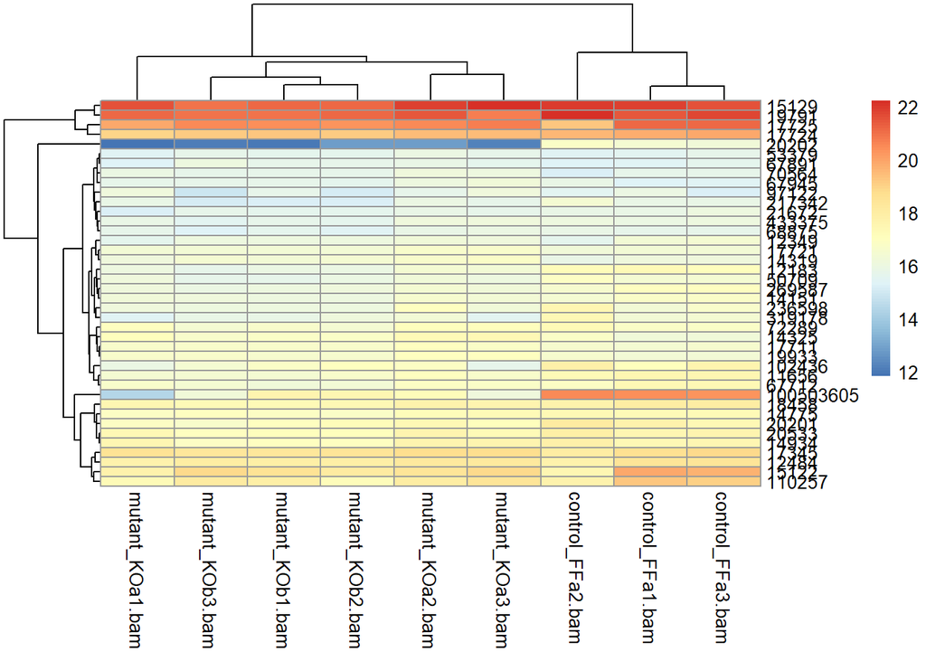

```r
# Load pheatmap library
library("pheatmap")

# Get dds normalized counts
dds_counts <- counts(dds, normalized = TRUE)

# Get normalized counts - 40 higher values
select <- order(rowMeans(dds_counts), decreasing = TRUE)[1:40]

# Heatmap of the rlog transformed data
pheatmap(assay(rld)[select, ])
```

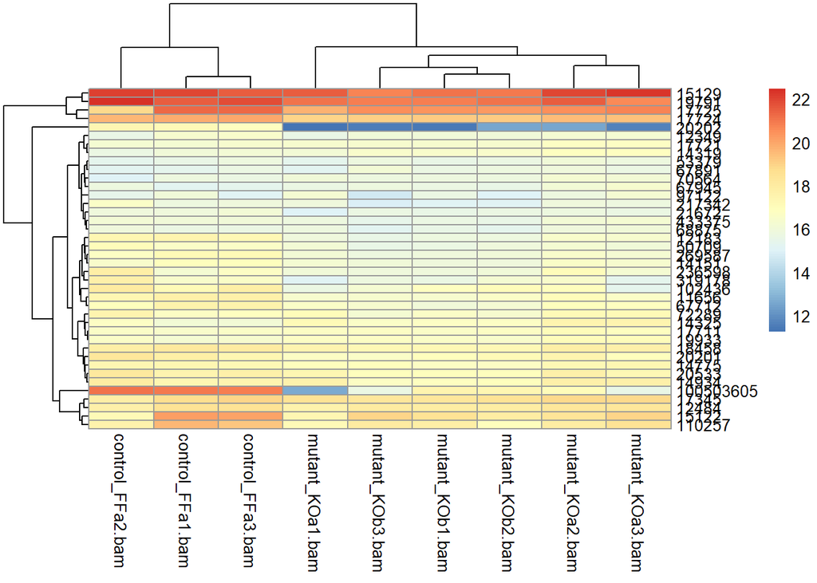

```r
# Heatmap of the vst transformed data
pheatmap(assay(vsd)[select, ])
```

Task 3.13 Generate a SDM to see the clustering of count data. (1 pts)

```r
# Generate a sample distance matrix (SDM) from rlog transformed data
sample_dist <- dist(t(assay(rld)))
class(sample_dist)
```

```
## [1] "dist"
```

```r
# Get SDM in matrix form
sdm <- as.matrix(sample_dist)
class(sdm)
```

```
## [1] "matrix" "array"
```

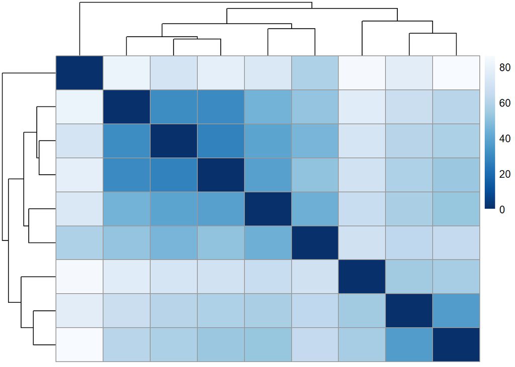

```r
# Load library
library("RColorBrewer")

# Add row names for clear plot
rownames(sdm) <- rld$Group
colnames(sdm) <- NULL

# Add colors
colors <- colorRampPalette(rev(brewer.pal(9, "Blues")))(255)

# Plot heatmap
pheatmap(sdm,
         clustering_distance_rows = sample_dist,
         clustering_distance_cols = sample_dist,
         col = colors)
```

Task 3.14 Perform the Principal Component Analysis using rlog method and find out the % significance values of first two principal components. (1 pts)

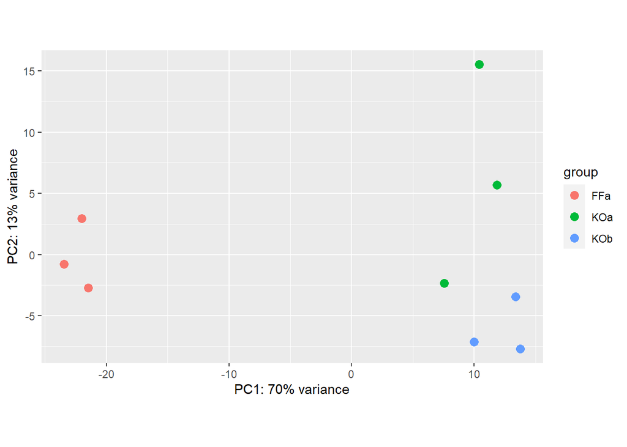

```r
# PCA plot on our rld transformed data
plotPCA(rld, intgroup = "condition")
```

Task 3.15 Repeat the PCA, this time using VST method and compare the plots with the ones obtained using rlog method. (1 pts)

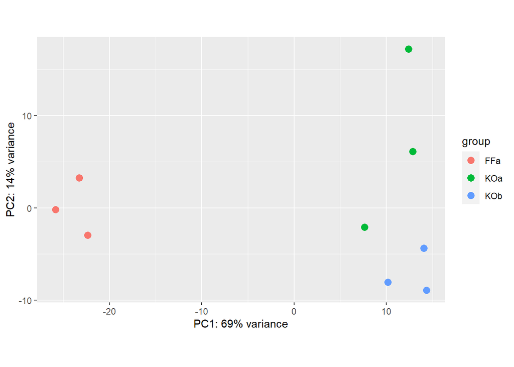

```r
# PCA plot on our vst transformed data
plotPCA(vsd, intgroup = "condition")
```

## R Markdown: ChIP-seq assessment

Task 3.16 Read in the two Myc Mel peakset replicates and create the common peakset as we did for our previous exercise. (1 pts)

```r
peakset1 <- ChIPQC:::GetGRanges("LMS_ChIPseq_short-master-2023-final/course/data/MacsPeaks/mycmelrep1_peaks.xls", sep="\t", simple=F)
peakset2 <- ChIPQC:::GetGRanges("LMS_ChIPseq_short-master-2023-final/course/data/MacsPeaks/mycmelrep2_peaks.xls", sep="\t", simple=F)

allpeaks <- c(peakset1,peakset2)
allpeaksreduced <- reduce(allpeaks)
allpeaksreduced
```

```
## GRanges object with 61883 ranges and 0 metadata columns:
##           seqnames          ranges strand
##              <Rle>       <IRanges>  <Rle>
##       [1]        1 3049670-3049833      *
##       [2]        1 3435991-3436154      *
##       [3]        1 4506720-4506910      *
##       [4]        1 4774935-4775285      *
##       [5]        1 4775337-4776102      *
##       ...      ...             ...    ...
##   [61879]        Y 1913013-1913289      *
##   [61880]        Y 1934470-1934640      *
##   [61881]        Y 1964602-1964765      *
##   [61882]        Y 2555745-2555908      *
##   [61883]        Y 2890951-2891338      *
##   -------
##   seqinfo: 22 sequences from an unspecified genome; no seqlengths
```

```r
common_peakset <- allpeaksreduced[allpeaksreduced %over% peakset1
                                  & allpeaksreduced %over% peakset2]

length(common_peakset)
```

```
## [1] 29183
```

```r
common_peakset[1:500,]
```

```
## GRanges object with 500 ranges and 0 metadata columns:
##         seqnames            ranges strand
##            <Rle>         <IRanges>  <Rle>
##     [1]        1   4775337-4776102      *
##     [2]        1   4847097-4848049      *
##     [3]        1   5072876-5073344      *
##     [4]        1   7078801-7079247      *
##     [5]        1   7387548-7388483      *
##     ...      ...               ...    ...
##   [496]        1 82574568-82574893      *
##   [497]        1 82622078-82622406      *
##   [498]        1 82624277-82624803      *
##   [499]        1 82721285-82721555      *
##   [500]        1 82767737-82768239      *
##   -------
##   seqinfo: 22 sequences from an unspecified genome; no seqlengths
```

Task 3.17 Now we can rank them by their fold enrichment, select the top 500 peaks and resize these peaks to 200bp around centre. (1 pts)

```r
allpeaks <- c(peakset1,peakset2)
allpeaks
```

```
## GRanges object with 94376 ranges and 7 metadata columns:
##           seqnames          ranges strand |        ID     Score      Strand
##              <Rle>       <IRanges>  <Rle> | <integer> <integer> <character>
##       [1]        1 3049670-3049833      * |       164   3049799           *
##       [2]        1 3435991-3436154      * |       164   3436060           *
##       [3]        1 4774935-4775285      * |       351   4775250           *
##       [4]        1 4775337-4775959      * |       623   4775616           *
##       [5]        1 4847544-4847931      * |       388   4847795           *
##       ...      ...             ...    ... .       ...       ...         ...
##   [94372]        Y   581955-582358      * |       404    582206           *
##   [94373]        Y   622263-622682      * |       420    622529           *
##   [94374]        Y   622802-623337      * |       536    623093           *
##   [94375]        Y 1903412-1903639      * |       228   1903501           *
##   [94376]        Y 1905483-1905649      * |       167   1905522           *
##           X.log10.pvalue. fold_enrichment X.log10.qvalue.                  name
##                 <numeric>       <numeric>       <numeric>           <character>
##       [1]         5.96807         4.61726          3.6137     mycmelrep1_peak_1
##       [2]         7.85614         5.56316          5.3628     mycmelrep1_peak_2
##       [3]         6.16280         4.18060          3.7841     mycmelrep1_peak_3
##       [4]        22.79415         9.52390         19.6478     mycmelrep1_peak_4
##       [5]        24.16184         7.45675         20.9733     mycmelrep1_peak_5
##       ...             ...             ...             ...                   ...
##   [94372]        29.01375         8.34254        25.53985 mycmelrep2_peak_41439
##   [94373]        11.11224         4.57042         8.29794 mycmelrep2_peak_41440
##   [94374]        23.41474         5.85560        20.10744 mycmelrep2_peak_41441
##   [94375]         9.13500         6.03422         6.44556 mycmelrep2_peak_41442
##   [94376]         7.98196         5.12232         5.36025 mycmelrep2_peak_41443
##   -------
##   seqinfo: 22 sequences from an unspecified genome; no seqlengths
```

```r
allpeaks_ranked <- allpeaks[rev(order(allpeaks$fold_enrichment))]
allpeaks_ranked
```

```
## GRanges object with 94376 ranges and 7 metadata columns:
##           seqnames              ranges strand |        ID     Score      Strand
##              <Rle>           <IRanges>  <Rle> | <integer> <integer> <character>
##       [1]        4   45965697-45967126      * |      1430  45966486           *
##       [2]        9   21155248-21158095      * |      2848  21157016           *
##       [3]       12 114345160-114346639      * |      1480 114345880           *
##       [4]        3   87846835-87847851      * |      1017  87847065           *
##       [5]        5 136577954-136578699      * |       746 136578211           *
##       ...      ...                 ...    ... .       ...       ...         ...
##   [94372]        9   35112910-35113195      * |       286  35112972           *
##   [94373]        6 103599074-103599289      * |       216 103599157           *
##   [94374]       MT           8876-9149      * |       274      9049           *
##   [94375]       MT         15961-16299      * |       339     16143           *
##   [94376]       12     3109823-3110192      * |       370   3109983           *
##           X.log10.pvalue. fold_enrichment X.log10.qvalue.                  name
##                 <numeric>       <numeric>       <numeric>           <character>
##       [1]         488.149        123.1159         479.841 mycmelrep1_peak_33018
##       [2]         437.832        111.5354         430.369 mycmelrep1_peak_48303
##       [3]         360.959        104.7455         354.200 mycmelrep1_peak_11995
##       [4]         378.718         96.9533         371.892 mycmelrep1_peak_30691
##       [5]         336.006         96.8103         329.475 mycmelrep1_peak_38571
##       ...             ...             ...             ...                   ...
##   [94372]         9.64043         1.44899         6.91125 mycmelrep2_peak_38439
##   [94373]         5.62593         1.41744         3.30866 mycmelrep1_peak_40861
##   [94374]         4.45468         1.38597         2.26553 mycmelrep1_peak_50991
##   [94375]         7.07424         1.36836         4.52042 mycmelrep2_peak_40270
##   [94376]         4.82115         1.31069         2.59632  mycmelrep1_peak_9928
##   -------
##   seqinfo: 22 sequences from an unspecified genome; no seqlengths
```

```r
commonpeaksreduced <- reduce(allpeaks_ranked)
commonpeaksreduced
```

```
## GRanges object with 61883 ranges and 0 metadata columns:
##           seqnames          ranges strand
##              <Rle>       <IRanges>  <Rle>
##       [1]        1 3049670-3049833      *
##       [2]        1 3435991-3436154      *
##       [3]        1 4506720-4506910      *
##       [4]        1 4774935-4775285      *
##       [5]        1 4775337-4776102      *
##       ...      ...             ...    ...
##   [61879]        Y 1913013-1913289      *
##   [61880]        Y 1934470-1934640      *
##   [61881]        Y 1964602-1964765      *
##   [61882]        Y 2555745-2555908      *
##   [61883]        Y 2890951-2891338      *
##   -------
##   seqinfo: 22 sequences from an unspecified genome; no seqlengths
```

```r
top_500 <- commonpeaksreduced[1:500]
top_500
```

```
## GRanges object with 500 ranges and 0 metadata columns:
##         seqnames            ranges strand
##            <Rle>         <IRanges>  <Rle>
##     [1]        1   3049670-3049833      *
##     [2]        1   3435991-3436154      *
##     [3]        1   4506720-4506910      *
##     [4]        1   4774935-4775285      *
##     [5]        1   4775337-4776102      *
##     ...      ...               ...    ...
##   [496]        1 45488762-45488989      *
##   [497]        1 45818319-45818499      *
##   [498]        1 45851785-45853176      *
##   [499]        1 45894688-45894960      *
##   [500]        1 45917279-45917526      *
##   -------
##   seqinfo: 22 sequences from an unspecified genome; no seqlengths
```

```r
commonpeaks <- resize(top_500,200,fix="center")
commonpeaks
```

```
## GRanges object with 500 ranges and 0 metadata columns:
##         seqnames            ranges strand
##            <Rle>         <IRanges>  <Rle>
##     [1]        1   3049652-3049851      *
##     [2]        1   3435973-3436172      *
##     [3]        1   4506715-4506914      *
##     [4]        1   4775010-4775209      *
##     [5]        1   4775620-4775819      *
##     ...      ...               ...    ...
##   [496]        1 45488776-45488975      *
##   [497]        1 45818309-45818508      *
##   [498]        1 45852381-45852580      *
##   [499]        1 45894724-45894923      *
##   [500]        1 45917303-45917502      *
##   -------
##   seqinfo: 22 sequences from an unspecified genome; no seqlengths
```

Task 3.18 Extract the sequences underneath the file and write them to FASTA file in you working directory. Inspect the file in notepad. (1 pts)

```r
library(BSgenome)
library(BSgenome.Mmusculus.UCSC.mm9)

genome <- BSgenome.Mmusculus.UCSC.mm9

seqlevelsStyle(commonpeaks) <- "UCSC"


commonpeaksequences <- getSeq(genome,GRanges(commonpeaks))

names(commonpeaksequences) <-  paste0("peak_",seqnames(commonpeaks),"_",
                                      start(commonpeaks),
                                      "-",
                                      end(commonpeaks))

commonpeaksequences[1:2]
```

```
## DNAStringSet object of length 2:
##     width seq                                               names
## [1]   200 AAGCGGGCCACCGACACACCGCT...CTTGTATTTCCCCATCCCTCCAC peak_chr1_3049652...
## [2]   200 TCCGAGAACAACCATGGGATGTT...TGATAAGCATCTATACTTCCCCT peak_chr1_3435973...
```

```r
writeXStringSet(commonpeaksequences,file="consensusPeaks.fa")
```